# Data Science Capstone - Next word prediction model

Szymon Tomczyk

July 2021

## 1. Executive summary

This is the first part of the Capstone Project of the Data Science Specialization offered by the Johns Hopkins University. This project aims to build an algorithm that will predict the next word in a text input by the user and present it in a form of a Shiny App. In this first part I will describe the acquisition, cleaning and exploratory analysis of the data that will be used to build the prediction algorithm. Moreover, I will present a brief outline of the methods that will be used to do the next word prediction

## 2. The project

The presented analysis will require the use of following R libraries:

- [tidyverse](https://www.tidyverse.org/)
- [cld2](https://cran.r-project.org/web/packages/cld2/index.html)
- [quanteda](https://quanteda.io/)

### 2.1 Downloading and loading the data into R

The corpora provided for this task comes from three sources: Twitter, blogs and news. The texts were provided in four different langues, for this project the texts in English will be further used.

#### The data is loaded into R

```r
blog <- file("Coursera-SwiftKey/final/en_US/en_US.blogs.txt")
blog.txt <- readLines(blog)

news <- file("Coursera-SwiftKey/final/en_US/en_US.news.txt")
news.txt <- readLines(news)

twitter <- file("Coursera-SwiftKey/final/en_US/en_US.twitter.txt")
twitter.txt <- readLines(twitter)
```

### 2.2 Data cleaning

#### Examination of the basic properties of the provided corpora

```r
data.frame(source=c("Blog","News", "Twitter"),
       `Number of texts`=c(length(blog.txt),length(news.txt), length(twitter.txt)),
       `Total number of words`=c(sum(sapply(tokens(blog.txt),length)),
                                 sum(sapply(tokens(news.txt),length)),
                                 sum(sapply(tokens(twitter.txt),length))))
```

```
   source Number.of.texts Total.number.of.words
1    Blog          899288              42818152
2    News         1010242              39849636
3 Twitter         2360148              36663968
```

```r
sample.blog <- sample(1:length(blog.txt),round(length(blog.txt)/20))
blog.txt.sub <- blog.txt[sample.blog]

sample.news <- sample(1:length(news.txt),round(length(news.txt)/20))
news.txt.sub <- news.txt[sample.news]

sample.twitter <- sample(1:length(twitter.txt),round(length(twitter.txt)/20))
twitter.txt.sub <- twitter.txt[sample.twitter]
```

#### Cleaning the corpora and tokenization

Now that we reduced the size of the data we can start the pre-processing of the texts. For this purpose we will use cld2 package that will evaluate the language of each text and allow us to keep only the texts in English.

```r
lng1 <- detect_language(blog.txt.sub)
lng2 <- detect_language(news.txt.sub)
lng3 <- detect_language(twitter.txt.sub)

data.frame(source=c("Blog","News", "Twitter"),
       `Number of Non-English texts` = c(sum(lng1 != "en", na.rm = T),
                                         sum(lng2 != "en", na.rm = T),
                                         sum(lng3 != "en", na.rm = T)))
```

```
   source Number.of.Non.English.texts
1    Blog                         221
2    News                         207
3 Twitter                         183
```

As we can see even though the corpora were pre-filtered for texts in foreign languages there are still some left to be removed.

```r
blog.txt.sub <- blog.txt.sub[lng1 =="en"]
news.txt.sub <- news.txt.sub[lng2 =="en"]
twitter.txt.sub <- twitter.txt.sub[lng3 =="en"]
```

In the next step we will combine the texts from the three sources to create a full corpus. This corpus will be further cleaned, tokenized and used to build the prediction model.

```r
blog.txt.sub <- data.frame(text = blog.txt.sub, source = "blog")
news.txt.sub <- data.frame(text = news.txt.sub, source = "news")
twitter.txt.sub <- data.frame(text = twitter.txt.sub, source = "twitter")

blog.txt.sub %>% bind_rows(news.txt.sub, twitter.txt.sub) -> all.txt.sub

c.all <- corpus(all.txt.sub)
```

Now, we can proceed with further cleaning and tokenization of the corpus. We will remove profanity words, puntuation, symbols, numbers and links. We will also remove the stop-words as it is a common practice in language processing.

```r
tk1 <- tokens(c.all, what = "word", remove_punct = T, remove_symbols = T,
                remove_numbers = T, remove_url = T, remove_separators = T)

profanity <- read_lines("bad-words.txt")
tk1 <- tokens_remove(tk1, pattern = profanity)

tk1 <- tokens_select(tk1, pattern = stopwords("en"), selection = "remove")
```

Using the tokenized corpus we produce the bigram and trigram collections that that will be neccessary for the prediction model.

```r
tk2 <- tokens_ngrams(tk1, n = 2)
tk3 <- tokens_ngrams(tk1, n = 3)
```

### 2.3 Exploratory Data Analysis

#### Examining the word frequency and other properties of the corpora

The world cloud of 100 most frequent words in our corpus

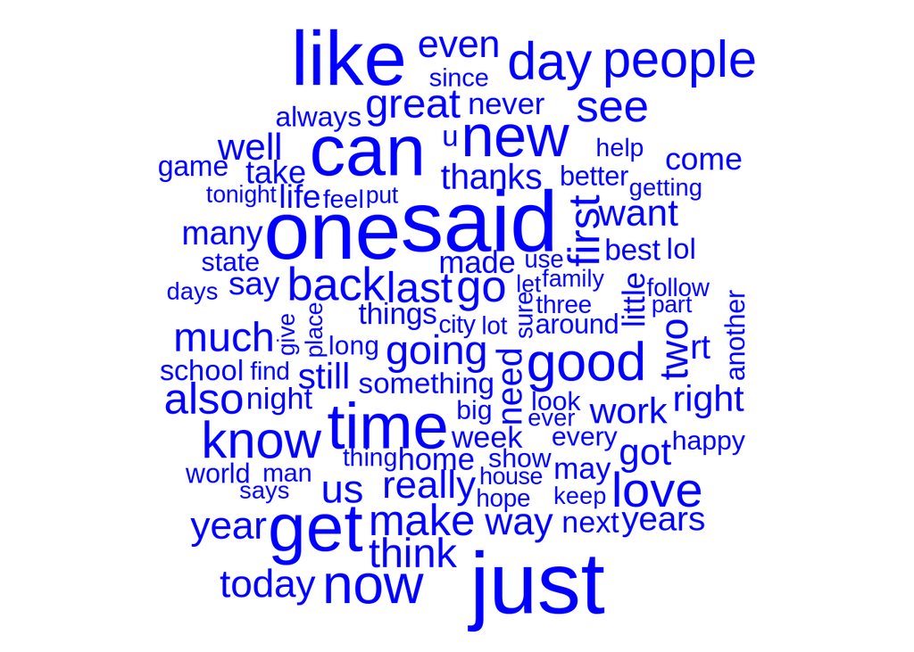

```r
tk1.freq <- textstat_frequency(dfm(tk1))
tk2.freq <- textstat_frequency(dfm(tk2))
tk3.freq <- textstat_frequency(dfm(tk3))

wordcloud(tk1.freq$feature, tk1.freq$frequency, max.words=100, colors = "blue")
```

The plots of top 10 most frequent uni-, bi- and trigrams in the corpus.

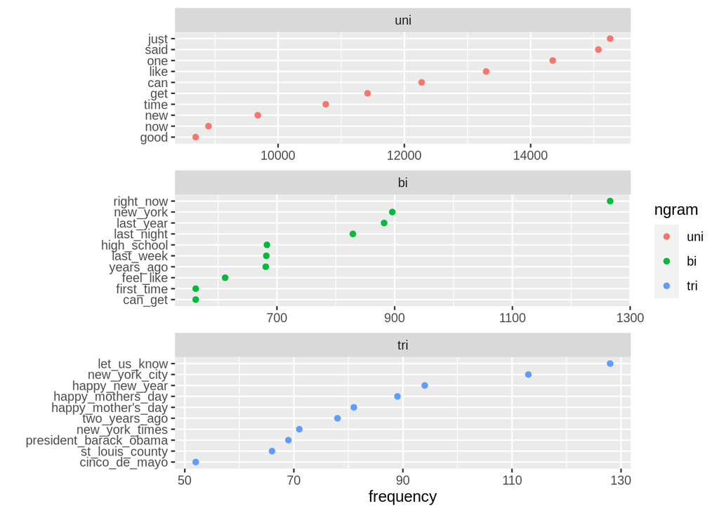

```r
as.data.frame(tk1.freq) %>% select(feature, frequency) %>%
        mutate(ngram = "uni") %>%
        slice(1:10) -> tk1.freq.to.plot

as.data.frame(tk2.freq) %>% select(feature, frequency) %>%
        mutate(ngram = "bi") %>%
        slice(1:10)-> tk2.freq.to.plot

as.data.frame(tk3.freq) %>% select(feature, frequency) %>%
        mutate(ngram = "tri") %>%
        slice(1:10)-> tk3.freq.to.plot

tk1.freq.to.plot %>% bind_rows(tk2.freq.to.plot, tk3.freq.to.plot) -> tk.to.plot
tk.to.plot$ngram <- factor(tk.to.plot$ngram, levels = c("uni", "bi", "tri"))

plot.freq <- ggplot(tk.to.plot, aes(x=frequency, y=reorder(feature, frequency))) +
        geom_point(aes(color=ngram)) + ylab("") +
        facet_wrap(.~ngram, ncol=1, scales = "free")
plot.freq
```

**How many unique words do you need in a frequency sorted dictionary to cover 50% of all word instances in the language? How many for 90%?**

```r
sum(cumsum(tk1.freq$frequency) <= sum(tk1.freq$frequency*0.5))
```

```
[1] 1009
```

```r
sum(cumsum(tk1.freq$frequency) <= sum(tk1.freq$frequency*0.9))
```

```
[1] 17851
```

**Now we take a look at how many uni-, bi- and trigrams appear only one, two or three times in the corpus.**

```r
tk1.fq.fq <- as_tibble(table(tk1.freq$frequency), .name_repair = "minimal")
tk2.fq.fq <- as_tibble(table(tk2.freq$frequency), .name_repair = "minimal")
tk3.fq.fq <- as_tibble(table(tk3.freq$frequency), .name_repair = "minimal")
data.frame(ngram=c("unigram", "bigram", "trigram"),
           x1=c(tk1.fq.fq[[2]][1],tk2.fq.fq[[2]][1],tk3.fq.fq[[2]][1]),
           x2=c(tk1.fq.fq[[2]][2],tk2.fq.fq[[2]][2],tk3.fq.fq[[2]][2]),
           x3=c(tk1.fq.fq[[2]][3],tk2.fq.fq[[2]][3],tk3.fq.fq[[2]][3]),
           `percent(x1)`=c(round(tk1.fq.fq[[2]][1]/length(tk1.freq$feature)*100,2),
                          round(tk2.fq.fq[[2]][1]/length(tk2.freq$feature)*100,2),
                          round(tk3.fq.fq[[2]][1]/length(tk3.freq$feature)*100,2)))
```

```
    ngram      x1     x2    x3 percent.x1.
1 unigram   80766  17923  8439       55.80
2  bigram 1529840 133494 41233       86.71
3 trigram 2181805  26904  4812       98.38
```

## 3. Observations

- The amount of text provided as a starting point to build our model is fairly large and causes an efficiency problem when the work is beeing done on a regular computer.
- Sampling only 5% of the provided corpus improves the efficiency of working with the data but may affect the accuracy of the predictions. Different starting sample size may need to be tested and evaluated to find the right accuracy – efficiency balance.
- There is a vast number of different NLP packages available for R but quantenda seems to be the most coherenet, complete and easy to use.
- A relatively low number of unique words make up a large proportion of the corpus.
- When the corpus is tokenized in bi- and trigrams majority of the tokens appear only once in the entire corpus.
- The previous two facts indicate that low frequency bi- and trigrams can likely be removed from the dataset without affecting the accuracy of the prediction. Reducing the dataset in this way will likely improve the efficiency of the algorithm but it’s impact on the accuracy will need to be evaluated.

## 4. Plans for building the prediction algorithm

After extensive research about the common practices in building n-gram prediction models and going half-way through with building a Katz’s back-off model with Linear Good Turing probability smoothing, I stumbled upon the paper published by [Brants et al.](https://aclanthology.org/D07-1090.pdf), the backoff model that they describe, named Stupid Backoff for its simplicity, offers a much simpler approach to the word prediction problem. Instead of probabilities, their model uses un-nomrmalized word frequencies with empiricaly set backoff weight. This model is much less computation hungry and easier to implement. I will try to use it for this assignment and test it’s accuracy. If the results are not satisfactory I will go back to the classic Katz’s back-off model.